# Movie Analytics with Neo4j: An End-to-End Example

An end-to-end walkthrough of analysing movie data with Neo4j, starting from the Movie graph that ships with every Neo4j installation. This post covers creating the dataset with Cypher, and then querying it to explore actors, directors, reviewers, and the relationships between them.

graph-rag

neo4j

LLM

Author

Mei-Chin Pang

Published

August 16, 2026

In this post we work through an end-to-end example of movie analytics with Neo4j. We start by building the graph, and then query it to answer questions about actors, directors, producers, writers, and the people who review the films.

# Create the Movie Dataset in Neo4j

We do not need to hunt for a dataset: the **Movie graph** ships with every Neo4j installation as a built-in example. It is the dataset behind the `:play movies` guide in Neo4j Browser, a small graph of around 170 nodes built from `Movie` and `Person` nodes connected by `ACTED_IN`, `DIRECTED`, `PRODUCED`, `WROTE`, `REVIEWED`, and `FOLLOWS` relationships. Being tiny, well known, and richly connected makes it ideal for learning Cypher and for demonstrating graph analytics.

**Tip**

In Neo4j Browser you can load the same data interactively by running `:guide movies` (or `:play movies` on older versions) and clicking through the guide. Running the Cypher below yourself is equivalent, and has the advantage that the whole dataset is reproducible from this page.

## Adding uniqueness constraints

Before importing, we add uniqueness constraints on the two identifying properties. Besides preventing duplicates, each constraint creates an index that makes the `MERGE` statements below much faster:

```
CREATE CONSTRAINT movie_title IF NOT EXISTS
FOR (m:Movie) REQUIRE m.title IS UNIQUE;

CREATE CONSTRAINT person_name IF NOT EXISTS
FOR (p:Person) REQUIRE p.name IS UNIQUE;
```

## Importing the movies, people, and reviews

The script below creates the entire Movie graph. It is written with `MERGE` throughout, so it is idempotent: running it twice will not create duplicate nodes or relationships. Each block introduces one film, the people involved in it, and the relationships that connect them, and the final block adds the reviewers and their `REVIEWED` and `FOLLOWS` relationships.

```
MERGE (TheMatrix:Movie {title:'The Matrix'})
  ON CREATE SET TheMatrix.released=1999,
TheMatrix.tagline='Welcome to the Real World'

MERGE (Keanu:Person {name:'Keanu Reeves'}) ON CREATE SET Keanu.born=1964
MERGE (Carrie:Person {name:'Carrie-Anne Moss'}) ON CREATE SET Carrie.born=1967
MERGE (Laurence:Person {name:'Laurence Fishburne'})
ON CREATE SET Laurence.born=1961
MERGE (Hugo:Person {name:'Hugo Weaving'}) ON CREATE SET Hugo.born=1960
MERGE (LillyW:Person {name:'Lilly Wachowski'}) ON CREATE SET LillyW.born=1967
MERGE (LanaW:Person {name:'Lana Wachowski'}) ON CREATE SET LanaW.born=1965
MERGE (JoelS:Person {name:'Joel Silver'}) ON CREATE SET JoelS.born=1952

MERGE (Keanu)-[:ACTED_IN {roles:['Neo']}]->(TheMatrix)
MERGE (Carrie)-[:ACTED_IN {roles:['Trinity']}]->(TheMatrix)
MERGE (Laurence)-[:ACTED_IN {roles:['Morpheus']}]->(TheMatrix)
MERGE (Hugo)-[:ACTED_IN {roles:['Agent Smith']}]->(TheMatrix)
MERGE (LillyW)-[:DIRECTED]->(TheMatrix)
MERGE (LanaW)-[:DIRECTED]->(TheMatrix)
MERGE (JoelS)-[:PRODUCED]->(TheMatrix)

MERGE (Emil:Person {name:'Emil Eifrem'}) ON CREATE SET Emil.born=1978
MERGE (Emil)-[:ACTED_IN {roles:["Emil"]}]->(TheMatrix);


MERGE (TheMatrixReloaded:Movie {title:'The Matrix Reloaded'})
  ON CREATE SET TheMatrixReloaded.released=2003,
  TheMatrixReloaded.tagline='Free your mind'

MERGE (Keanu:Person {name:'Keanu Reeves'}) ON CREATE SET Keanu.born=1964
MERGE (Carrie:Person {name:'Carrie-Anne Moss'}) ON CREATE SET Carrie.born=1967
MERGE (Laurence:Person {name:'Laurence Fishburne'})
  ON CREATE SET Laurence.born=1961
MERGE (Hugo:Person {name:'Hugo Weaving'}) ON CREATE SET Hugo.born=1960
MERGE (LillyW:Person {name:'Lilly Wachowski'}) ON CREATE SET LillyW.born=1967
MERGE (LanaW:Person {name:'Lana Wachowski'}) ON CREATE SET LanaW.born=1965
MERGE (JoelS:Person {name:'Joel Silver'}) ON CREATE SET JoelS.born=1952

MERGE (Keanu)-[:ACTED_IN {roles:['Neo']}]->(TheMatrixReloaded)
MERGE (Carrie)-[:ACTED_IN {roles:['Trinity']}]->(TheMatrixReloaded)
```

[output cut: 740 more lines]

```
MERGE (JamesThompson)-[:REVIEWED {
  summary:'The coolest football movie ever', rating:100}]->(TheReplacements)
MERGE (AngelaScope)-[:REVIEWED {
  summary:'Pretty funny at times', rating:62}]->(TheReplacements)
MERGE (JessicaThompson)-[:REVIEWED {
  summary:'Dark, but compelling', rating:85}]->(Unforgiven)
MERGE (JessicaThompson)-[:REVIEWED {
  summary:"Slapstick redeemed only by the Robin Williams and
  Gene Hackman's stellar performances", rating:45}]->(TheBirdcage)
MERGE (JessicaThompson)-[:REVIEWED {
  summary:'A solid romp', rating:68}]->(TheDaVinciCode)
MERGE (JamesThompson)-[:REVIEWED {
  summary:'Fun, but a little far fetched', rating:65}]->(TheDaVinciCode)
MERGE (JessicaThompson)-[:REVIEWED {
  summary:'You had me at Jerry', rating:92}]->(JerryMaguire);
```

## Inspecting the schema

Before writing queries, it helps to see the shape of the graph we have just created. Neo4j keeps track of every label and relationship type it has seen, and exposes that summary through a built-in procedure:

```
CALL db.schema.visualization
```

`CALL` invokes a stored procedure rather than running a pattern match, and `db.schema.visualization` returns two collections: the `nodes` it has observed (one per label) and the `relationships` between them (one per relationship type). The Neo4j Browser renders those collections as a small graph, so the result is a *meta-graph*: each circle is a **label**, not an individual node, and each arrow is a **relationship type**, not an individual relationship.

**Note**

The procedure reads from the database’s internal token store, not from the data itself, so it is fast even on large graphs. The flip side is that it describes what *can* exist rather than what does: a label or relationship type that was created and later deleted may still appear until the store is recomputed.

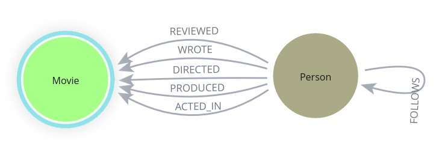

Figure 1: The Movie graph schema: two labels, `Movie` and `Person`, joined by five relationship types pointing from `Person` to `Movie`, plus a self-referencing `FOLLOWS` relationship between people.

Figure 1 confirms that the import behaved as intended. There are only two labels, `Movie` and `Person`, and every relationship carrying a person’s contribution to a film, `ACTED_IN`, `DIRECTED`, `PRODUCED`, `WROTE`, and `REVIEWED`, points from `Person` to `Movie`. The loop on `Person` is `FOLLOWS`, the one relationship that connects people to each other and gives the reviewers a small social network of their own. Knowing these directions matters: an arrow drawn the wrong way in a query pattern is one of the most common reasons a Cypher query silently returns no rows.

With the graph in place, we can start asking questions of it.

# CRUD operations in Cypher

Before working through the query patterns in detail, it is worth seeing the four basic operations that every database supports, **create**, **read**, **update**, and **delete**, expressed in Cypher. Unlike SQL, which uses a different statement for each one (`INSERT`, `SELECT`, `UPDATE`, `DELETE`), Cypher builds all four from a small set of clauses:

Table 1: The CRUD operations and the Cypher clauses that implement them.

| Operation | Cypher clause |
| --- | --- |
| Create | `CREATE`, or `MERGE` when duplicates must be avoided |
| Read | `MATCH` combined with `WHERE` and `RETURN` |
| Update | `SET` to write properties, `REMOVE` to drop them |
| Delete | `DELETE`, or `DETACH DELETE` for connected nodes |

The clauses in Table 1 combine freely, which is why an update is written as a `MATCH` followed by a `SET` rather than as a statement of its own. The examples below use a film that is *not* part of the Movie graph, *Inception*, so that the dataset built above is left untouched. The last example removes it again, which means the whole sequence can be run and re-run safely.

## Creating a node

`CREATE` writes a new node into the graph:

```
//Query : Creating a Node
CREATE (m:Movie {title: 'Inception', released: 2010, duration: 148})
RETURN m
```

The pattern inside `CREATE` is written exactly like a `MATCH` pattern: `m` is the variable, `:Movie` is the label the new node is given, and the map in braces supplies its properties. Because `CREATE` always inserts, running this query twice would normally produce two identical *Inception* nodes; here the uniqueness constraint on `Movie.title` created earlier rejects the second attempt with an error instead. `RETURN m` hands the newly created node back so the browser can draw it.

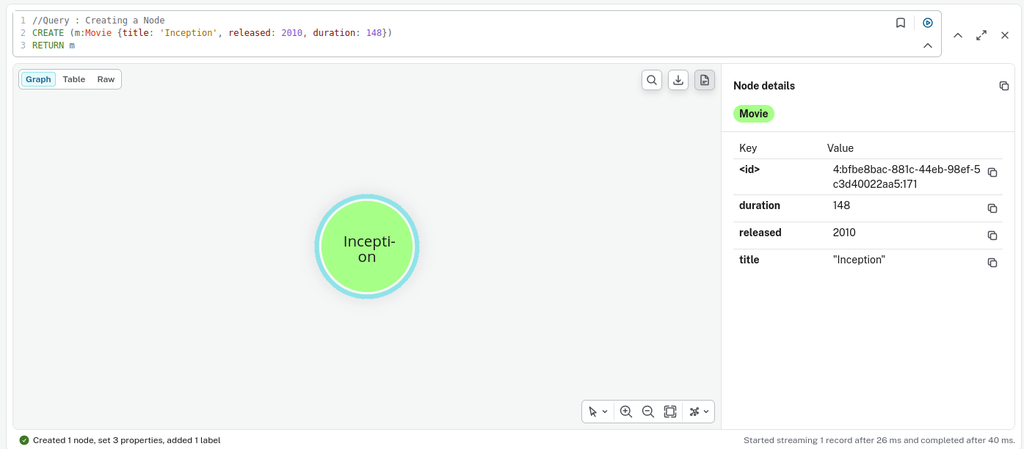

Figure 2: The new `Movie` node drawn on its own, with the details panel listing the three properties it was given. The status bar underneath confirms what the write actually did: one node created, three properties set, and one label added.

Figure 2 shows the result. The node floats unconnected because nothing links it to the rest of the graph yet, and the caption is truncated to “Incepti-on” only because the browser is wrapping the text inside the circle. The `<id>` in the details panel is the internal element identifier Neo4j assigned to the node; it is not a property we set and should not be relied on as a key, which is precisely why the import script identifies films by `title` instead.

**Tip**

Use `MERGE` rather than `CREATE` whenever a node might already exist. `MERGE` matches the pattern first and only creates it if nothing was found, which is why the whole import script above is idempotent. `CREATE` is the right choice only when the data is known to be new.

## Creating a relationship

Nodes on their own carry little information; the value of a graph lies in the edges between them. The query below adds an actor and connects him to the film we just created:

```
//Query: Creating a Relationship
CREATE (a:Person {name: 'Leonardo DiCaprio'})
WITH a
MATCH (m:Movie {title: 'Inception'})
CREATE (a)-[:ACTED_IN]->(m)
RETURN a, m
```

Three things are happening here. The first `CREATE` makes the `Person` node. `WITH a` then passes that node on to the rest of the query, which is necessary because a `MATCH` cannot follow a `CREATE` directly; `WITH` acts as a pipe between query parts, carrying forward only the variables it names. The `MATCH` finds the existing *Inception* node, and the second `CREATE` draws the relationship between the two. Note that the relationship pattern `(a)-[:ACTED_IN]->(m)` reuses the variables `a` and `m` without repeating their labels or properties, because both nodes are already bound.

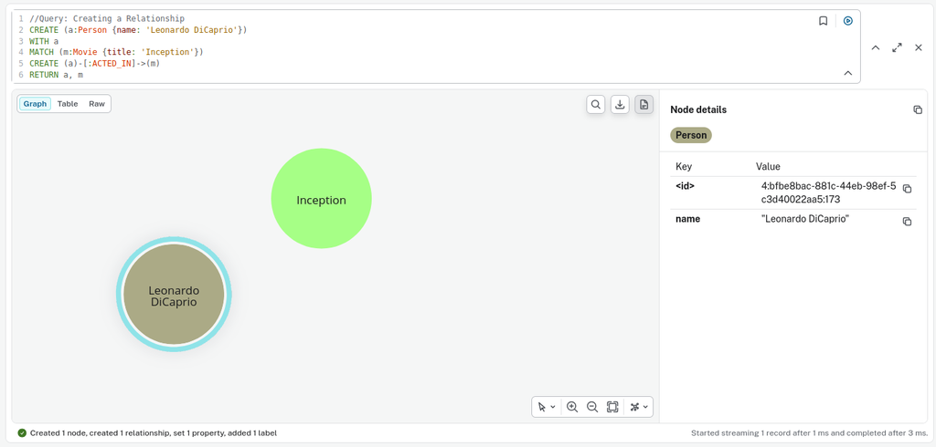

Figure 3: The two nodes returned by the query, with the details panel showing the newly created `Person`. The status bar reports one node created, one relationship created, one property set, and one label added.

Figure 3 is worth looking at carefully, because the picture and the status bar appear to disagree. The bar confirms that a relationship *was* created, yet no arrow is drawn between the two circles. Nothing has gone wrong: `RETURN a, m` asked for the two nodes and nothing else, and the browser draws only what the query returned. Adding the relationship to the result makes it visible:

```
MATCH (a:Person {name: 'Leonardo DiCaprio'})-[r:ACTED_IN]->(m:Movie)
RETURN a, r, m
```

Naming the relationship `r` in the pattern binds it to a variable in the same way `a` and `m` bind the nodes, and returning it gives the browser the edge to draw.

**Warning**

The arrow direction is part of the data, not decoration. Writing `(m)-[:ACTED_IN]->(a)` would store the claim that the film acted in the person, and later queries written the conventional way round would silently miss it.

## Reading data

Reading is what the rest of this post is about, but its simplest form is a `MATCH` followed by a `RETURN`:

```
//Query: Reading Data
MATCH (m:Movie)
RETURN m.title, m.released
```

`MATCH (m:Movie)` binds every film in the graph to `m`, and the `RETURN` picks two properties from each one. Since the result is made of plain values rather than nodes, the browser shows a table.

## Reading data with a filter

Adding a `WHERE` clause between `MATCH` and `RETURN` narrows the rows down:

```
//Query: Reading Data with a Filter
MATCH (m:Movie)
WHERE m.released > 2000
RETURN m.title, m.released
```

The `MATCH` still produces every film, and `WHERE` then keeps only those for which the condition evaluates to `true`. Section 4 works through the filtering techniques that build on this pattern.

## Updating a node

`SET` overwrites the value of an existing property:

```
//Query: Updating a Node
MATCH (m:Movie {title: 'Inception'})
SET m.duration = 150
RETURN m
```

An update is always a read followed by a write: the `MATCH` locates the node first, and `SET` then changes it. Every node the pattern matches is updated, so a `MATCH` that is too loose will change more of the graph than intended. Here the inline `{title: 'Inception'}` filter pins the match to a single film.

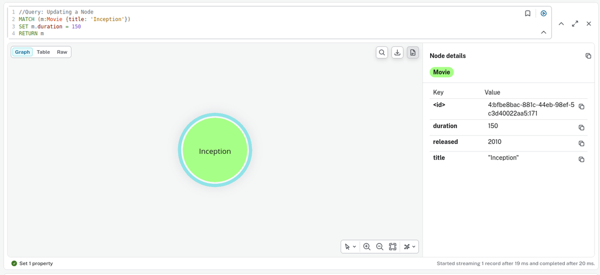

Figure 4: The updated node, with `duration` now 150 in the details panel while `released` and `title` are untouched. The status bar reads “Set 1 property”, confirming that a single write took place.

Figure 4 shows that `SET` is surgical: only the property named on the left of the `=` is written, and the rest of the node is left exactly as it was. The `<id>` is also unchanged from Figure 2, which confirms that this is the same node being modified in place rather than a replacement. Because `SET` overwrites unconditionally, the previous value of 148 is gone; Cypher keeps no history, so recovering it would mean writing it back explicitly.

## Adding a new property

The same clause also creates properties that did not exist before:

```
//Query: Adding a New Property
MATCH (m:Movie {title: 'Inception'})
SET m.genre = 'Science Fiction'
RETURN m
```

Cypher makes no distinction between changing a property and adding one: because Neo4j is schema-flexible, `SET` simply writes the key and value onto the node. Nothing forces the other `Movie` nodes to acquire a `genre` property as well, which is convenient but also the reason a misspelled property name returns `null` rather than an error. `REMOVE m.genre` would take the property away again.

## Deleting a node

Finally, `DETACH DELETE` removes a node together with everything attached to it:

```
//Query: Deleting a Node
MATCH (m:Movie {title: 'Inception'})
DETACH DELETE m
```

Neo4j refuses to delete a node that still has relationships, because doing so would leave dangling edges behind. `DETACH` instructs it to remove the node’s relationships first, so this single statement deletes both the *Inception* node and the `ACTED_IN` edge created earlier. A plain `DELETE m` would fail here, and is only appropriate for isolated nodes. There is no `RETURN` because the node no longer exists once the statement completes.

**Note**

The `Person` node for Leonardo DiCaprio survives this deletion; only the film and its relationships are gone. Running `MATCH (p:Person {name: 'Leonardo DiCaprio'}) DELETE p` restores the Movie graph to exactly the state the import script produced.

# Matching nodes and returning properties

Every query in this post follows the same three-part skeleton:

```
MATCH
WHERE
RETURN
```

`MATCH` states the pattern to find, `WHERE` filters the rows that pattern produced, and `RETURN` says which parts of them to hand back. Only `MATCH` and `RETURN` are required; `WHERE` is optional. Reading a query in that order is usually enough to work out what it does. This section covers the two ends of that skeleton, the simplest patterns and the two ways of returning what they match; Section 4 takes up the middle.

## Returning whole nodes

The simplest possible query asks for all nodes of one kind:

```
MATCH (m:Movie)
RETURN m
```

`MATCH` describes a pattern to look for in the graph, and here the pattern is as small as it can be: a single node. Inside the parentheses, `m` is a **variable** we invent so we can refer to the matched node later, and `:Movie` is a **label** that restricts the search to movie nodes. Because there is nothing else in the pattern, no relationships and no property filter, the pattern matches every `Movie` node in the database. `RETURN m` then hands each matched node back as a result row, with all of its properties (`title`, `released`, `tagline`) attached.

**Note**

The label is what keeps this query fast. Thanks to the constraint we created earlier, Neo4j has an index on `Movie` nodes and can jump straight to them instead of scanning the whole store. Dropping the label and writing `MATCH (m) RETURN m` would return every node in the database, people included.

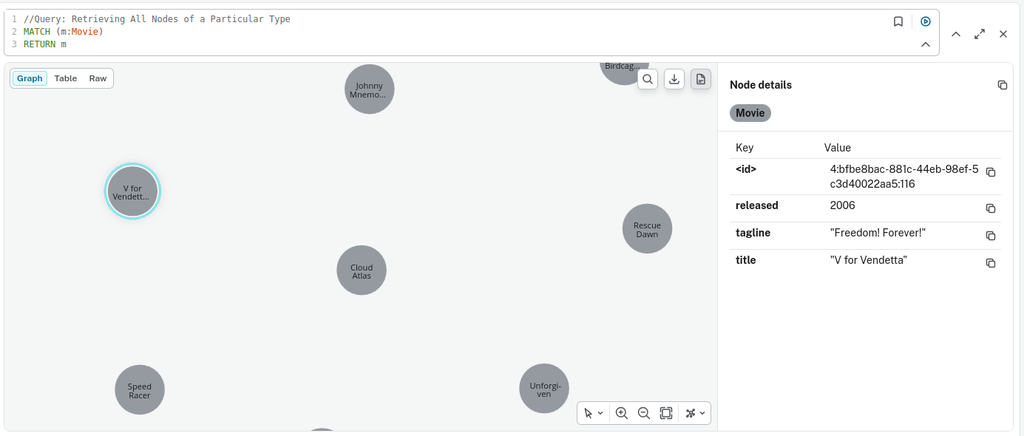

Figure 5: A sample of the `Movie` nodes returned by the query, drawn as isolated circles labelled with each film’s title.

Figure 5 shows part of the result in the Neo4j Browser. Note that the nodes float unconnected: the query asked only for movies, so the people and the `ACTED_IN`, `DIRECTED`, and `REVIEWED` relationships that join them are simply not part of the result. The browser draws what the query returned, not the surrounding graph. To bring the relationships back we would have to put them in the pattern, for example `MATCH (p:Person)-[r]->(m:Movie) RETURN p, r, m`.

The same pattern works for any label. Swapping `Movie` for `Person` returns every `Person` node in the graph, actors, directors, producers, writers, and reviewers alike, because `Person` is the only label the import gave them:

```
MATCH (n:Person)
RETURN n
```

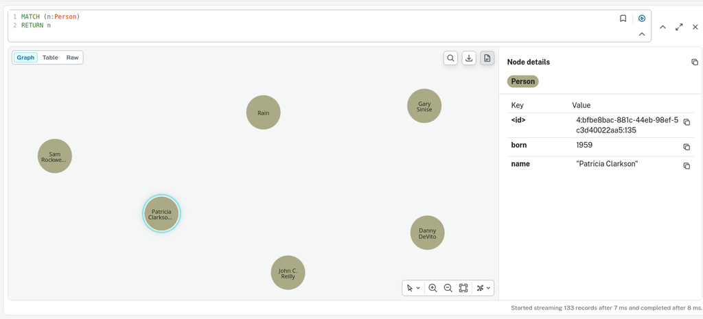

Figure 6: Matching on the label alone again gives a set of isolated circles, one per person, with the `name` property as the caption. The browser truncates long names to fit inside the circle, but the full value is available in the details panel when a node is selected.

## Returning specific properties

Returning whole nodes is convenient for exploring, but most of the time we want a few named values rather than every property. Instead of returning the variable itself, we return properties of it using dot notation:

```
// Query: Retrieving Specific Properties
MATCH (m:Movie)
RETURN m.title, m.releaseYear
```

The `MATCH` clause is unchanged: it still binds every `Movie` node to `m`. What changes is the `RETURN`. Writing `m.title` asks for the value of the `title` property on the matched node, so each result row now holds two scalar values rather than one node object. The line beginning with `//` is a Cypher comment and is ignored when the query runs.

Because the result is made of plain values instead of nodes, the Neo4j Browser has nothing to draw and shows a table instead of a graph. The column headers are taken literally from the expressions we wrote, which is why they read `m.title` and `m.releaseYear`.

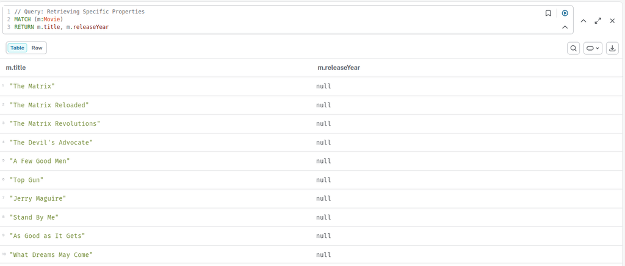

Figure 7: Every movie title is returned correctly, but the `m.releaseYear` column is entirely `null` because no such property exists on these nodes.

Figure 7 shows an important Cypher behaviour. The titles come back as expected, but every value in the second column is `null`. Nothing has gone wrong with the data: the property is simply not called `releaseYear`. We created it as `released`, and asking for a property a node does not have returns `null` rather than raising an error.

**Warning**

This silent `null` is a common source of confusion. Cypher has no fixed schema, so it cannot know whether `releaseYear` is a typo or a property that only some nodes happen to carry. If a column comes back entirely `null`, suspect a misspelled property name first. Running `CALL db.propertyKeys` lists every property name the database knows about, which is a quick way to check the spelling.

Correcting the name gives the intended result:

```
MATCH (m:Movie)
RETURN m.title, m.released
```

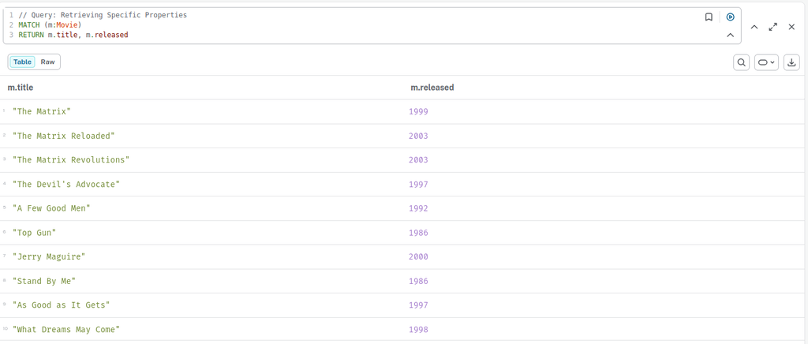

Figure 8: With the property name spelled correctly, the second column is filled with the release year of each film.

Figure 8 shows the same table with real values: 1999 for *The Matrix*, 2003 for both *Reloaded* and *Revolutions*, and so on. The browser also renders the two columns differently, quoting the titles as strings while showing the years as bare numbers, which is a useful visual confirmation that `released` was stored as an integer rather than as text.

# Filtering results

So far every query has returned all 38 movies. To narrow the result down to the films we are actually interested in, we add a `WHERE` clause. `WHERE` sits between `MATCH` and `RETURN` and acts as a predicate on the rows that `MATCH` produced: each candidate row is tested against the condition, and only the rows for which it evaluates to `true` survive to the `RETURN`. The examples below work through the filtering techniques that come up most often, starting with the simplest.

## Filtering on an exact property value

The most direct filter tests a property for equality, which is how we pick a single named node out of the graph:

```
//Query: Filtering Based on Properties
MATCH (m:Movie)
WHERE m.title = 'The Matrix'
RETURN m
```

`MATCH (m:Movie)` still describes every film, but `WHERE m.title = 'The Matrix'` reduces the candidates to the one whose `title` property is exactly that string. Cypher’s `=` is case-sensitive and compares the whole value, so `'the matrix'` would match nothing. Because `RETURN m` hands back the node itself rather than its properties, the browser has something to draw and shows a graph rather than a table.

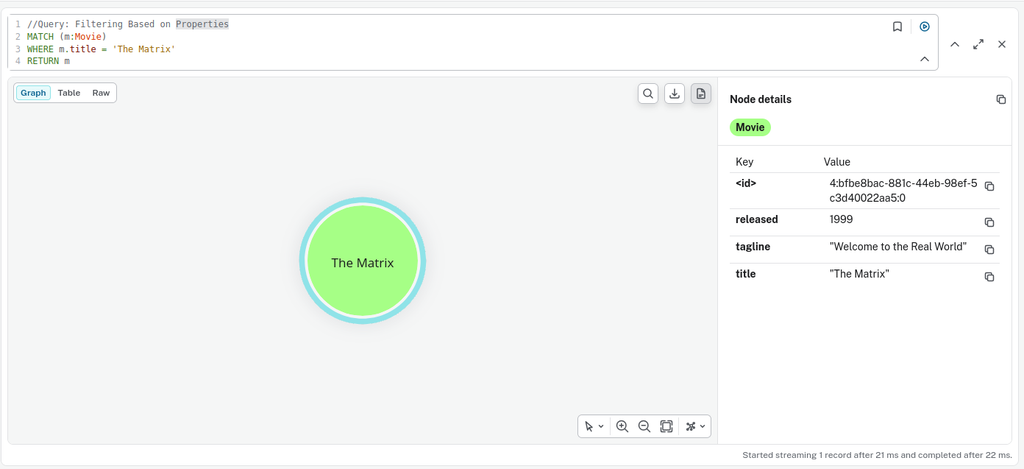

Figure 9: Filtering on `m.title` returns a single `Movie` node. The details panel on the right shows all of its properties, `released` 1999, `tagline` “Welcome to the Real World”, and `title` “The Matrix”, together with the internal `<id>` Neo4j assigned to it.

Figure 9 shows the result: one green circle, and one record streamed back in 22 ms. The filter is fast because the uniqueness constraint we created at the start put an index behind `Movie.title`, so Neo4j looks the value up directly instead of scanning all 38 films.

An equality test like this one can also be written inline in the pattern:

```
MATCH (m:Movie {title: 'The Matrix'})
RETURN m
```

The two queries are equivalent and the planner treats them the same way. The inline form is more compact, but it only supports exact matches, which is why `WHERE` remains the general tool for everything that follows.

## Filtering on a numeric range

Swapping `=` for a comparison operator turns the same clause into a range filter:

```
//Query: Filtering Results
MATCH (m:Movie)
WHERE m.released > 2000
RETURN m.title, m.released
```

Because `released` is stored as an integer, `>` performs a numeric comparison; had the values been strings, the same expression would have compared them lexicographically and given misleading results.

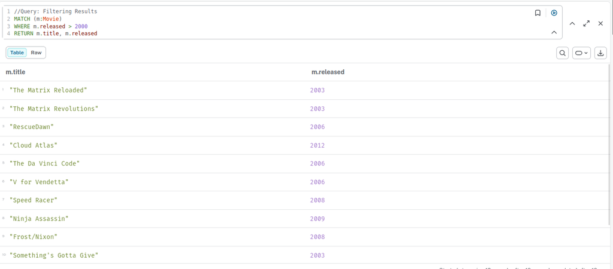

## Combining and negating conditions

Several predicates can be joined with `AND`, `OR`, and `NOT`. Using `AND` to combine two comparisons turns the open-ended filter above into a bounded window:

```
//Query: Filtering with Logical Operators
MATCH (m:Movie)
WHERE m.released >= 2000 AND m.released <= 2010
RETURN m.title, m.released
```

Both operands are evaluated against the same row, so a film is kept only if it satisfies the lower bound *and* the upper bound. Note that both comparisons are inclusive this time: `>=` keeps the films released exactly in 2000 that the strict `>` in Figure 10 discarded.

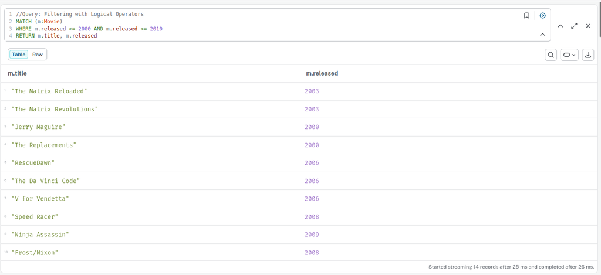

Figure 11: The 14 films released between 2000 and 2010 inclusive. *Jerry Maguire* and *The Replacements*, both from 2000, appear because the lower bound uses `>=` rather than the strict `>` used earlier.

`OR` and `NOT` complete the set, and can be mixed with `AND` in one predicate:

```
MATCH (m:Movie)
WHERE m.released >= 2000 AND m.released <= 2010
  AND NOT m.title = 'The Matrix Reloaded'
RETURN m.title, m.released
ORDER BY m.released
```

`AND` binds more tightly than `OR`, so parentheses are worth adding whenever the two are combined. The same range reads more clearly with the `IN` operator when the values are a fixed set rather than an interval, as in `WHERE m.released IN [1999, 2003, 2012]`.

## Matching on strings

Equality is too blunt an instrument for text, so Cypher adds three operators for partial matches, `STARTS WITH`, `ENDS WITH`, and `CONTAINS`:

```
// Query: Filtering with Regular Expressions
MATCH (m:Movie)
WHERE m.title STARTS WITH 'The'
RETURN m.title
```

`STARTS WITH` tests whether the property begins with the given prefix, so a film qualifies on the strength of its first three characters alone and the rest of the title is ignored. All three operators are case-sensitive, which matters here: a title stored as `'the Matrix'` would not match `'The'`. `ENDS WITH` and `CONTAINS` work the same way on the suffix and on any position in the string respectively, so `WHERE m.title CONTAINS 'Matrix'` would find the trilogy wherever the word appeared in the title.

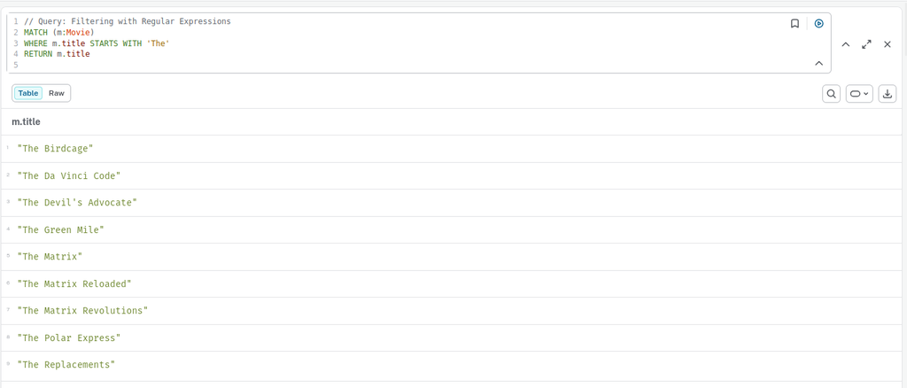

Figure 12: The films whose titles begin with “The”, listed alphabetically. Prefix matching is purely textual, so *The Matrix*, *The Matrix Reloaded*, and *The Matrix Revolutions* all qualify on their first three characters, as do unrelated films such as *The Birdcage* and *The Polar Express*.

Figure 12 shows the result, and the alphabetical ordering is worth noticing: no `ORDER BY` was written, but the rows arrive sorted anyway. That is a side effect of the index behind `Movie.title`, which stores values in sorted order and can be scanned from the point where `'The'` begins. This is why prefix matching is efficient while the other two operators are not: `ENDS WITH` and `CONTAINS` cannot use the index that way and fall back to examining every value.

For anything more elaborate than a prefix, suffix, or substring, the `=~` operator matches a property against a full regular expression:

```
MATCH (m:Movie)
WHERE m.title =~ '(?i)the matrix.*'
RETURN m.title
```

The `(?i)` flag makes the match case-insensitive, so the lowercase pattern still matches the capitalised titles. The trailing `.*` is needed because `=~` matches the whole value rather than a fragment of it, so without it only *The Matrix* itself would qualify.

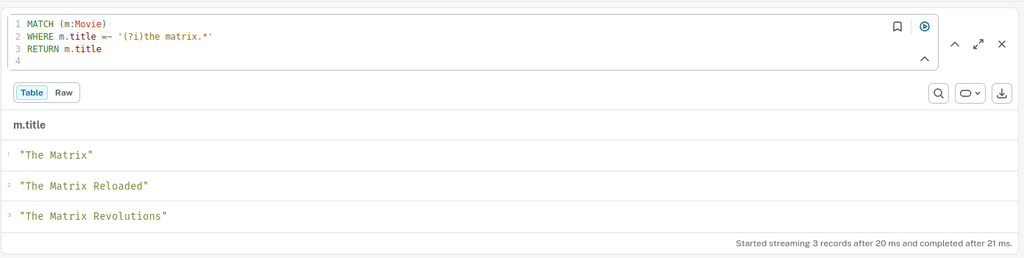

Figure 13: The regular expression matches the three Matrix films and nothing else. The lowercase pattern still finds the capitalised titles thanks to the `(?i)` flag.

## Filtering across a pattern

Everything so far has filtered a single node, but the predicate does not have to apply to the node the query starts from. Once relationships are in the pattern, a `WHERE` clause on one end filters the whole path:

```
// Query: Pattern-Based Filtering
MATCH (a:Person)-[:ACTED_IN]->(m:Movie)
WHERE m.released > 2000
RETURN a.name, m.title, m.released
```

The predicate is exactly the one from Figure 10, but the pattern around it has grown: instead of matching films on their own, the query walks the `ACTED_IN` relationship first and then discards any path whose film falls outside the range. Filtering and traversing compose freely in this way, which is what makes `WHERE` the general tool it is.

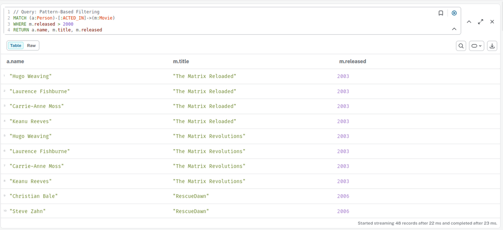

## Filtering on the existence of a relationship

A pattern can also be placed inside the `WHERE` clause itself, in which case Cypher tests only whether the traversal succeeds and does not add its rows to the result:

```
MATCH (p:Person)
WHERE NOT (p)-[:ACTED_IN]->()
RETURN p.name
```

The difference from the previous query is important. There, `ACTED_IN` was part of the `MATCH` pattern, so the relationship shaped the result and produced one row per traversal. Here it is a predicate, so the result still holds one row per person and the pattern acts purely as a yes-or-no test. Negated with `NOT`, it returns the people who never acted, the directors, producers, writers, and reviewers, and we return to exactly this query in Section 6.2. Dropping the `NOT` gives the opposite set.

## Filtering on a collected list

Every filter so far has tested one row at a time. Sometimes the condition we want applies to a *group* of rows instead, for instance “films with more than one actor”. That requires collapsing the rows into a list first, and Cypher does it with `WITH`:

```
//Query: Using List Functions
MATCH (m:Movie)<-[:ACTED_IN]-(a:Person)
WITH m, collect(a) AS actors
WHERE size(actors) > 1
RETURN m.title, size(actors) AS NumberOfActors
```

Four things are worth unpacking here.

The pattern is written right-to-left, `(m:Movie)<-[:ACTED_IN]-(a:Person)`, with the arrowhead on the left. This is the same relationship as `(a:Person)-[:ACTED_IN]->(m:Movie)` used earlier, just read from the film’s point of view; Cypher allows either direction to be written, and the choice is purely one of readability.

`WITH` acts as a pipeline stage: it takes the rows produced so far, reshapes them, and passes the result to the next clause. It behaves exactly like `RETURN` except that the query continues afterwards instead of ending. Here it keeps `m` and replaces the many person rows with a single aggregated value.

`collect(a)` is the aggregating function doing that work. Where `count` reduces a group of rows to a number, `collect` gathers the values into a list. Because `m` is the only non-aggregated expression in the `WITH`, it becomes the implicit grouping key, so the many rows for one film collapse into one row holding that film and a list of its cast.

`size(actors)` then measures the list, and the `WHERE` that follows filters on that measurement. The position of the `WHERE` is the essential point: it sits *after* the `WITH`, so it is applied to the aggregated rows rather than the raw ones. Placing it before the `WITH` would filter individual person-film pairs, which is a different question entirely and could not reference `actors` at all.

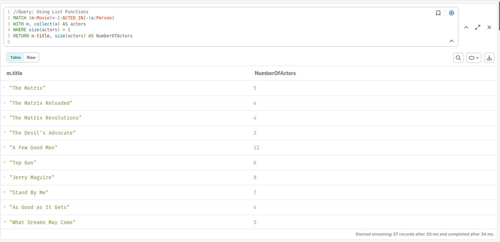

Figure 15: One row per film with a cast list longer than one, showing the film’s title alongside the number of actors in it. *A Few Good Men* leads with 12, while *The Matrix* has 5 because Emil Eifrem is counted alongside the four principal cast members.

Figure 15 returns 37 rows out of the 38 films in the graph. The one missing film is the single-cast entry that `size(actors) > 1` filters out. The counts also line up with the import script: *The Matrix* shows 5 rather than 4 because Emil Eifrem was added to its cast, and both *Matrix* sequels show 4.

**Tip**

`size(collect(a))` and `count(a)` give the same number here, and `count` is cheaper because it never materialises the list. `collect` earns its keep when the list itself is needed, for example returning `[x IN actors | x.name] AS castNames` alongside the count, or testing its contents with `any()`, `all()`, or `none()`.

**Note**

The `null` behaviour we met earlier matters throughout this section. A predicate that evaluates to `null`, which is what happens when the property is missing, is not `true`, so those nodes are dropped just as if the comparison had failed. Filtering on a misspelled property name therefore returns no rows at all rather than an error. To keep nodes that lack the property, test for it explicitly with `WHERE m.released IS NULL OR m.released > 2000`.

# Following relationships

Relationships have appeared only in passing so far, as a way of narrowing a filter. They are what makes a graph database useful in their own right, and they are written into the pattern with a hyphen, square brackets, and an arrow, so `(p)-[r:ACTED_IN]->(m)` reads as “`p` has an `ACTED_IN` relationship pointing to `m`”:

```
MATCH (p:Person)-[r:ACTED_IN]->(m:Movie)
RETURN p, r, m
```

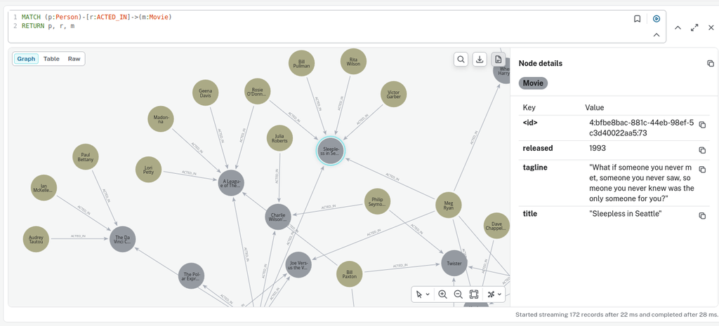

Figure 16: Returning the nodes and the relationship together produces a connected graph: 172 `ACTED_IN` edges linking actors (light circles) to the films they appeared in (dark circles). Selecting a node opens the details panel, here showing the `released`, `tagline`, and `title` properties of *Sleepless in Seattle*.

The variables work the same way on both sides: `p` binds to the person, `m` to the movie, and `r` to the relationship joining them. Returning all three gives the browser real nodes and edges to draw, so unlike Figure 5 the result appears as a connected graph rather than isolated circles. The arrow direction matters, and it must match the direction shown in Figure 1: `ACTED_IN` runs from `Person` to `Movie`, so writing the pattern the other way round would return nothing.

As before, we can return properties instead of whole entities. Relationships carry properties too, and `ACTED_IN` stores the `roles` an actor played:

```
MATCH (p:Person)-[r:ACTED_IN]->(m:Movie)
RETURN p.name, m.title, r.roles
```

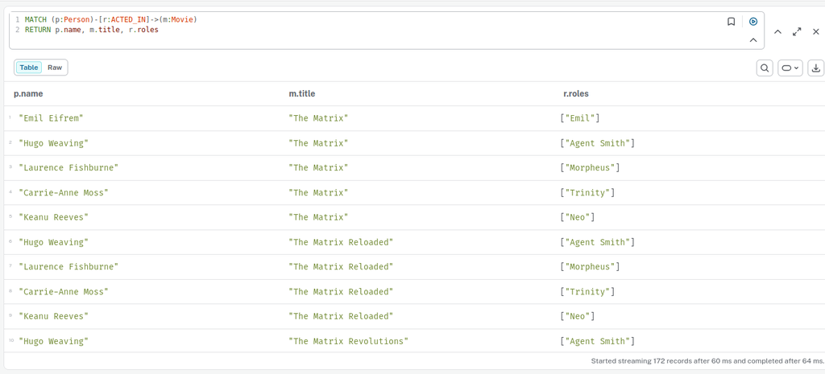

Figure 17: One row per `ACTED_IN` relationship with a total of 172 relationships, naming the actor, the film, and the list of characters they played. The `r.roles` column comes from the relationship rather than either node, and is displayed as a list because that is how it was stored.

Each row now names an actor, a film, and the list of characters they played in it. The same person appears once per film, so Hugo Weaving is listed separately as “Agent Smith” in *The Matrix*, *The Matrix Reloaded*, and *The Matrix Revolutions*.

**Note**

Returning properties always produces a table (never a graph). The Neo4j Browser can only draw a visualisation when the result contains nodes or relationships as whole entities, as in `RETURN p, r, m`. As soon as the `RETURN` lists properties such as `p.name` or `r.roles`, the values are plain strings, numbers, and lists with no identity or connections attached, so the Graph tab disappears and only the Table and Raw views remain. The same rule is what makes aggregations undrawable, as Section 6.4 explains.

Adding a `WHERE` clause narrows the traversal to one starting point, which is the most common shape of all:

```
MATCH (p:Person)-[r:ACTED_IN]->(m:Movie)
WHERE p.name = 'Tom Hanks'
RETURN p, m, r
```

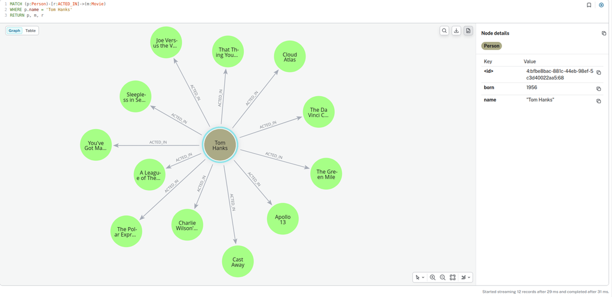

Figure 18: The 12 films Tom Hanks appeared in, drawn as a star with the single `Person` node at the centre and one `ACTED_IN` arrow reaching out to each `Movie`. The details panel on the right shows the properties of the selected node, `born` 1956 and `name` “Tom Hanks”, together with its internal `<id>`.

Here the filter applies to the node at one end of the pattern, and because `Person.name` is backed by the uniqueness constraint we created at the start, Neo4j uses the index to find Tom Hanks directly and then walks outwards along his `ACTED_IN` relationships. This is the essential difference from a relational database: rather than joining a large table, the query starts from one node and follows the connections it already holds. Figure 18 shows the result: a single starting node surrounded by the twelve films reached in one hop.

# Aggregation

Rather than listing rows, we often want to summarise them. Cypher does this with aggregating functions: `count`, `avg`, `sum`, `min`, and `max` all collapse the rows handed to them by `MATCH` into a single value, and any expression in the `RETURN` that is *not* an aggregation silently becomes the grouping key. This section works through each of them on the Movie graph, and along the way meets two traps that catch beginners: aggregating a property that does not exist, and traversing a relationship type the graph never had.

**Note**

Cypher keywords and function names are case-insensitive, so `COUNT(m)` and `count(m)` are the same function. Some queries below are written in upper case to match the style commonly used in tutorials and others in lower case; they behave identically. Only the labels, relationship types, property names, and string values are case-*sensitive*.

## Counting nodes

The simplest aggregating function is `count`, which reduces a set of rows to their number:

```
//Query: Counting Nodes
MATCH (m:Movie)
RETURN count(m) AS NumberOfMovies
```

`MATCH` again produces one row per `Movie` node, but `count(m)` collapses those rows into a single value: the number of rows it was given. Aggregation in Cypher is implicit, so there is no `GROUP BY` to write. Anything that is not an aggregating expression in the `RETURN` becomes the grouping key, and here there is nothing else, so the whole result is reduced to one row.

The `AS NumberOfMovies` part is an **alias**. Without it the column would be headed `count(m)`, which is how the expression was written. Aliasing gives the column a readable name, and is also what lets a later clause refer back to the value.

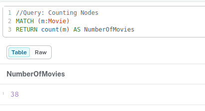

Figure 19: The whole result set collapses to a single row: the Movie graph contains 38 films.

Figure 19 confirms that the import created 38 `Movie` nodes, which matches the size of the built-in Movie graph. Since the script uses `MERGE` throughout, running it a second time and re-running this count will still return 38, which is a quick way to verify that the import is idempotent.

The same shape counts any label, so swapping `Movie` for `Person` counts the people instead:

```
MATCH (p:Person)
RETURN count(p)
```

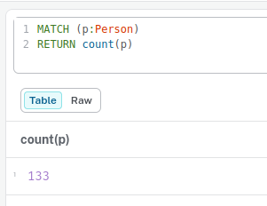

Figure 20: Counting `Person` nodes returns 133, fewer than the 172 `ACTED_IN` relationships in Figure 17.

**Tip**

`count(m)` counts rows in which `m` is not `null`, whereas `count(*)` counts every row regardless. The distinction matters once optional patterns are involved. To count only distinct values, for instance the number of different release years, use `count(DISTINCT m.released)`.

## Counting nodes versus counting relationships

The two counts above invite an obvious question, given the traversals of Section 5: how many people are there really in the graph? At first glance the numbers look contradictory: 133 people in Figure 20, but 172 `ACTED_IN` relationships in Figure 17. They are counting different things. `count(p)` counts **nodes**, one per person, whereas the earlier traversal counted **rows**, one per `ACTED_IN` relationship. There are two plausible explanations for the difference:

- *Actors with several films add rows.* The pattern `(p:Person)-[r:ACTED_IN]->(m:Movie)` produces one row per relationship, so Tom Hanks contributes 12 rows, Keanu Reeves 7, and Hugo Weaving 5. Each is a single node but many relationships.
- *Many people never acted.* Directors, producers, and writers such as Nora Ephron, Joel Silver, and Frank Darabont are `Person` nodes carrying only `DIRECTED`, `PRODUCED`, or `WROTE` relationships, and the four reviewers have only `REVIEWED` and `FOLLOWS`. None of them appear among the 172 rows at all.

To count the people who actually acted, rather than the relationships they accumulated, we deduplicate with `DISTINCT`:

```
MATCH (p:Person)-[:ACTED_IN]->(:Movie)
RETURN count(DISTINCT p) AS NumberOfActors
```

This is the `count(DISTINCT ...)` form mentioned earlier, and it returns a value smaller than both 133 and 172. Note also that `r` has been dropped from the pattern and the second node left anonymous as `(:Movie)`: a variable is only needed when something later in the query refers to it.

## Breaking the totals down by relationship type

Rather than running one query per relationship type, we can ask for all six at once and let Cypher group the results:

```
MATCH (p:Person)-[r:ACTED_IN|DIRECTED|PRODUCED|WROTE|REVIEWED|FOLLOWS]->()
RETURN type(r) AS relationshipType,
       count(r) AS total,
       count(DISTINCT p) AS distinctPeople
ORDER BY total DESC
```

Three pieces of syntax are doing the work here. The vertical bars inside the square brackets are a **type disjunction**: `[r:ACTED_IN|DIRECTED|...]` matches a relationship whose type is any one of those listed, so a single `MATCH` covers every kind of contribution a person can make. The node at the far end is left as an empty `()`, which matches anything; that matters because five of the types point at a `Movie` while `FOLLOWS` points at another `Person`, and an anonymous node accommodates both. Finally, `type(r)` returns the relationship’s type as a string, and because it is the only expression in the `RETURN` that is not an aggregation, it becomes the implicit grouping key. Cypher therefore produces one row per relationship type, exactly as `GROUP BY type(r)` would in SQL.

The two count columns then answer different questions within each group. `count(r)` counts the relationships themselves, while `count(DISTINCT p)` counts how many different people contribute them. `ORDER BY total DESC` sorts the groups from most to least common, and it can refer to `total` because the alias is established in the `RETURN`.

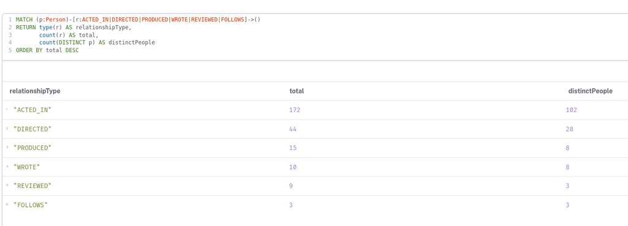

Figure 21: All six relationship types in one table, sorted by frequency. The `total` column counts relationships and `distinctPeople` counts the people producing them, so the gap between the two columns shows how much repeat contribution each type involves.

Figure 21 summarises the whole graph in six rows. `ACTED_IN` dominates with 172 relationships from 102 distinct people, which is the number the previous `count(DISTINCT p)` query returned, and it is comfortably smaller than the 133 `Person` nodes in Figure 20. Next come 44 `DIRECTED` relationships from 28 directors and 15 `PRODUCED` from 8 producers, followed by 10 `WROTE` from 8 writers. The two smallest rows belong to the reviewers: 9 `REVIEWED` and 3 `FOLLOWS`, both from just 3 people, since Paul Blythe follows Angela Scope without having reviewed anything himself.

The 102 and the 133 count different populations, which is worth spelling out. The 133 is every node carrying the `Person` label, anyone who appears in the graph in any capacity at all. The 102 is the number of people reached by the pattern `(p:Person)-[:ACTED_IN]->()`, so `count(DISTINCT p)` deduplicates the 172 rows and counts Tom Hanks once rather than twelve times, but a person is only counted at all if they have at least one `ACTED_IN` relationship to begin with. The 31-person gap is made up of people whose only relationships are of some other type: directors such as Nora Ephron, Ron Howard, and Frank Darabont, producers such as Joel Silver and Stefan Arndt, writers such as David Mitchell and Jim Cash, and the four reviewers. None of them ever acted, so the traversal never binds them to `p` and they contribute no rows to deduplicate. The two effects therefore push in opposite directions: repeat actors make 172 relationships larger than 102 people, while non-acting people make 102 smaller than the 133 nodes in total, giving $102 < 133 < 172$. The excluded group can be confirmed directly, and returns 31:

```
MATCH (p:Person)
WHERE NOT (p)-[:ACTED_IN]->()
RETURN count(p) AS NeverActed
```

The ratio between the two columns is the interesting part. `PRODUCED` at 15 relationships from 8 people and `REVIEWED` at 9 from 3 are the most lopsided, reflecting prolific producers such as Joel Silver and the handful of reviewers who rated several films each. `FOLLOWS` is the only type where the numbers coincide, because each of the three people follows exactly one other person.

## Why aggregations never produce a graph view

Every count so far has come back as a table rather than a picture, and the browser makes the reason visible:

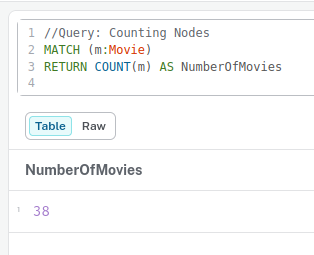

Figure 22: Thirty-eight `Movie` nodes are matched but only one row is returned, headed `NumberOfMovies` after the alias rather than `COUNT(m)`. Only the Table and Raw tabs are offered: the aggregation has replaced the nodes with a plain number, so there is nothing left for the browser to draw as a graph.

Figure 22 is the `count` query of Section 6.1 as the browser renders it, and the missing Graph tab is the point worth dwelling on.

The Neo4j Browser draws a visualisation only when the result set contains nodes or relationships as whole entities, because those are the only values that carry an identity and a set of connections to draw. This is the same rule we met when returning properties in Figure 17, but aggregation makes it unavoidable rather than merely likely.

An aggregating function is by definition a *reduction*: it takes many rows and returns a single value of a scalar type, a number for `COUNT`, `AVG`, `SUM`, `MIN`, and `MAX`. The node identities that went in do not come out. `COUNT(m)` yields the integer 38, which knows nothing about which 38 films were counted or how they connect to anyone, so the browser has no vertices to place and no edges to route. The Graph tab is therefore absent, not empty.

`collect` is the instructive exception. It aggregates without reducing to a scalar, gathering the matched nodes into a list and keeping their identities intact, so `MATCH (m:Movie) RETURN collect(m)` *does* render as a graph. If you want both the summary and the picture, keep the entities alongside the number:

```
MATCH (p:Person)-[r:ACTED_IN]->(m:Movie)
WHERE p.name = 'Tom Hanks'
RETURN p, collect(m) AS films, count(m) AS total
```

The `count` column is still a scalar, but `p` and the collected films give the browser something to draw, so the Graph tab reappears.

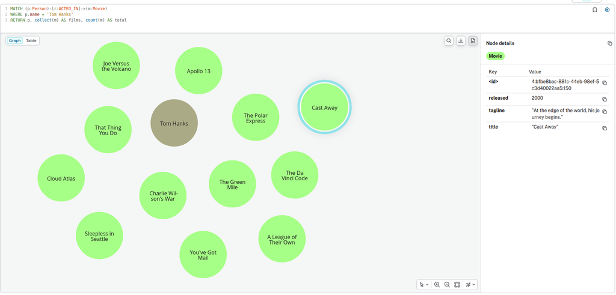

Figure 23: The Graph tab is available again because `p` and the nodes inside `films` are whole entities rather than scalars. Tom Hanks appears as the single brown `Person` circle and the twelve films he acted in as green `Movie` circles, with *Cast Away* selected so its `released`, `tagline`, and `title` properties appear in the details panel. No arrows are drawn between them: the pattern bound the `ACTED_IN` relationships to `r`, but `r` was never returned, so the browser has the nodes without the edges that connect them.

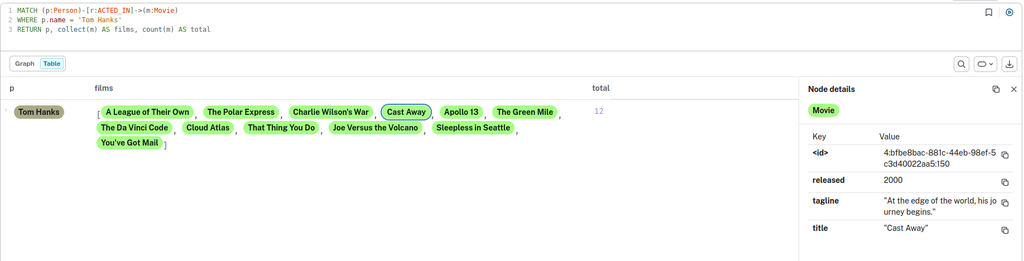

Figure 24: The same result seen through the Table tab. Everything has collapsed to a single row, because `p` is the only non-aggregated expression and therefore the grouping key. The `films` column holds one list of twelve `Movie` chips rather than twelve separate rows, and `total` holds the scalar 12 that `count(m)` reduced those rows to.

Figure 23 and Figure 24 are the same result set drawn two ways, which is what makes the pair useful. Both tabs are offered because the row contains entities; had we returned `p.name` instead of `p`, and dropped `collect`, only the Table tab would have survived, exactly as in Figure 22.

The contrast between them also shows what aggregation did to the row count. The `MATCH` produced twelve rows, one per `ACTED_IN` relationship, and both `collect(m)` and `count(m)` consumed all twelve. `collect` folded them into one list value and `count` into one integer, so a single row emerges carrying both. The twelve circles in Figure 23 are the *contents* of that one list being unpacked for drawing, not twelve separate result rows.

Adding `r` to the `RETURN` restores the missing arrows:

```
MATCH (p:Person)-[r:ACTED_IN]->(m:Movie)
WHERE p.name = 'Tom Hanks'
RETURN p, collect(r) AS roles, collect(m) AS films, count(m) AS total
```

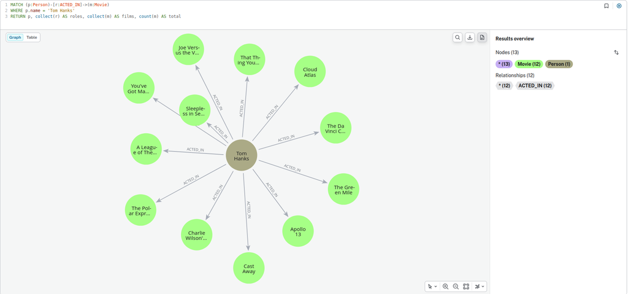

Figure 25: With the relationships collected as well, the browser has edges to route and the star shape of Figure 18 returns. The results overview on the right confirms what the row now contains: 13 nodes, 12 `Movie` and 1 `Person`, together with 12 `ACTED_IN` relationships. Nothing about the data has changed since Figure 23; the only difference is that `r` is now returned rather than merely bound by the pattern.

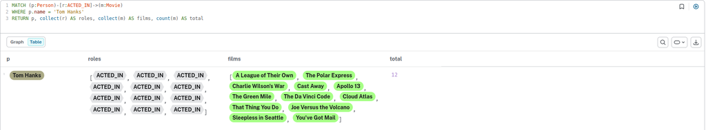

Figure 26: The Table tab for the same query. It is still a single row, but `roles` now sits between `p` and `films` holding a list of twelve `ACTED_IN` chips, one per relationship, while `total` remains the scalar 12. The three columns illustrate the difference between the two kinds of aggregation side by side: `collect` preserves twelve values, `count` reduces them to one.

Figure 25 redraws the star shape of Figure 18 while still reporting the count, and Figure 26 shows the same result as one row. Comparing the two tables is the clearest summary of the whole callout: in Figure 26 the `roles` and `films` lists carry twelve entities each, which is what the browser draws, while `total` carries a single number, which it cannot.

## Calculating the average

Swapping the function changes what is computed from the group, but not how the group is formed:

```
//Query: Calculating the Average
MATCH (m:Movie)
RETURN AVG(m.released) AS AverageReleaseYear
```

`AVG` takes the arithmetic mean of a numeric expression across all the rows in the group. Because `released` was stored as an integer, the mean is a genuine number rather than a lexicographic accident, and the result is returned as a floating-point value somewhere in the late 1990s. Averaging a year is statistically a little odd, but it is a compact way of asking “when is this collection of films centred?”.

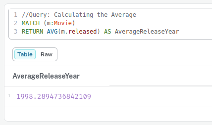

Figure 27: The 38 release years collapse to a single mean of 1998.2894736842109. Only the Table and Raw tabs are offered, for the reason given in Section 6.4: `AVG` has reduced the matched nodes to one scalar. The value is shown in full floating-point precision rather than rounded, and `ROUND(AVG(m.released), 1)` would trim it.

**Tip**

`AVG` ignores `null` values rather than treating them as zero, and it divides by the number of *non-null* rows. That is usually what you want, but it also means the denominator is invisible: a mean computed over three of thirty-eight films looks no different from one computed over all thirty-eight. Returning `count(m.released)` alongside the average makes the sample size explicit.

## Summing values

`SUM` adds the values in the group instead of averaging them:

```
//Query: Summing Values
MATCH (m:Movie)
RETURN SUM(m.duration) AS TotalDuration
```

This query is syntactically perfect and semantically useless on our graph: it returns `0`. The reason is the one we met in Figure 7, where `m.releaseYear` came back entirely `null`. The Movie graph stores only `title`, `released`, and `tagline` on its film nodes, so `m.duration` evaluates to `null` on all 38 rows. `SUM` skips `null`s, and summing nothing at all gives the identity element of addition, which is zero.

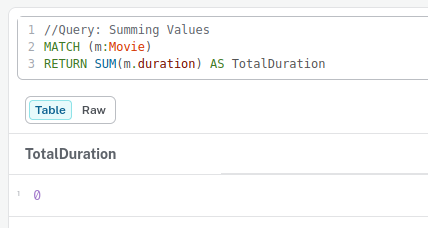

Figure 28: A single row headed `TotalDuration` holding `0`. Nothing has failed: the query matched all 38 films and returned a well-formed answer, but `duration` is not a property the Movie graph carries, so every value `SUM` was given was `null`.

**Warning**

The contrast with the other functions is worth remembering. Over an entirely `null` column, `SUM` returns `0`, `COUNT` returns `0`, but `AVG`, `MIN`, and `MAX` all return `null`, because there is no meaningful mean or extreme of an empty set whereas an empty sum is well defined. A `0` from `SUM` is therefore ambiguous: it can mean “the values added up to zero” or “there were no values”. `CALL db.propertyKeys` again settles which of the two you are looking at.

To make the query meaningful, the property has to exist first. Adding it to a single film is enough to see the behaviour change:

```
MATCH (m:Movie {title: 'The Matrix'})
SET m.duration = 136
RETURN m.title, m.duration
```

Re-running the `SUM` now returns 136 rather than 0, since one row contributes a value and the other 37 are still skipped.

## Finding minimum and maximum values

`MIN` and `MAX` return the smallest and largest value in the group, and because several aggregations may appear in one `RETURN`, both can be computed in a single pass:

```
//Query: Finding Minimum and Maximum Values
MATCH (m:Movie)
RETURN MIN(m.released) AS EarliestRelease,
       MAX(m.released) AS LatestRelease
```

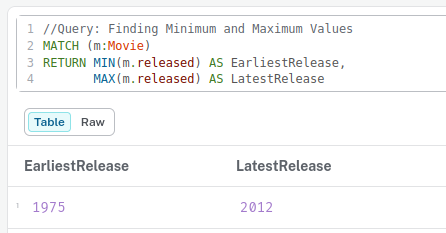

Figure 29: Two aggregations in one `RETURN` give two columns in a single row, `EarliestRelease` 1975 and `LatestRelease` 2012. Both share the same 38-row group produced by `MATCH (m:Movie)`, so the pattern is scanned once rather than twice.

On the Movie graph this returns 1975 and 2012, the years of *One Flew Over the Cuckoo’s Nest* and *Cloud Atlas*. Note what the query does **not** give us: the titles. `MIN` returns the extreme *value*, discarding the row it came from, so there is no `m` left to ask for a title. Recovering the film means sorting and taking the first rows instead:

```
MATCH (m:Movie)
RETURN m.title, m.released
ORDER BY m.released ASC
LIMIT 5
```

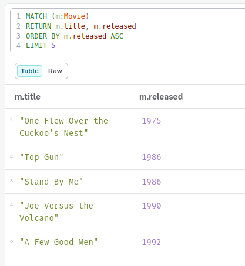

Figure 30: The five oldest films in the graph, sorted by `released` ascending. The first row, *One Flew Over the Cuckoo’s Nest* at 1975, carries the same year `MIN` returned in Figure 29, but here the title comes with it.

Figure 30 is the same information as the `EarliestRelease` column of Figure 29, expanded into rows that keep their identity. `ORDER BY ... ASC` sorts the 38 films from oldest to newest and `LIMIT 5` keeps the top of that list, so the first row is the minimum and the rest give it context: *Top Gun* and *Stand By Me* tie on 1986, followed by *Joe Versus the Volcano* in 1990 and *A Few Good Men* in 1992. Reversing the sort with `DESC` would put *Cloud Atlas* and the 2012 end of the range at the top instead, and `LIMIT 1` would return the single extreme row.

The tie at 1986 is also a reminder of what `MIN` and `MAX` cannot tell you. Both return one value, so a shared extreme is invisible; sorting exposes it.

Both `MIN` and `MAX` work on strings and dates as well as numbers, comparing them lexicographically and chronologically respectively.

## Grouping and aggregating

Adding a non-aggregated expression to the `RETURN` turns a single total into one row per group. The query below is the first in this section to do that, and it also contains two mistakes that are instructive to walk through:

```
//Query: Grouping and Aggregating
MATCH (m:Movie)
RETURN m.released COUNT(m) AS MoviesPerYear
ORDER BY m.releaseYear
```

The first problem is a syntax error. There is no comma between `m.released` and `COUNT(m)`, so Cypher cannot tell where one return item ends and the next begins, and the query is rejected before it ever touches the data. The second is the familiar misspelling: `ORDER BY m.releaseYear` sorts on a property that does not exist, so even once the comma is added every sort key would be `null` and the rows would come back in an arbitrary order. Correcting both gives a query that works:

```
MATCH (m:Movie)
RETURN m.released, COUNT(m) AS MoviesPerYear
ORDER BY m.released
```

`m.released` is not an aggregation, so it becomes the implicit grouping key and Cypher returns one row per distinct release year with the number of films in it.

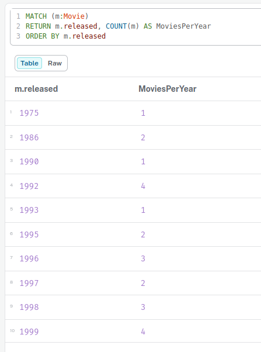

Figure 31: One row per release year rather than one per film, sorted ascending. The `m.released` column holds the grouping key and `MoviesPerYear` the size of each group, so the 38 `Movie` nodes collapse into roughly two dozen rows.

Figure 31 begins at 1975 with a single film, the *One Flew Over the Cuckoo’s Nest* row that `MIN` and the sorted query both picked out earlier, and runs forward from there: 2 films in 1986, 1 in 1990, 4 in 1992, then 1, 2, 3, 2, 3, and 4 through to 1999. Most years contribute one or two, with 1992 and 1999 the busiest of those visible.

The grouping key is what makes this different from every aggregation before it. `COUNT(m)` still reduces rows to a number, but it now does so once per distinct value of `m.released` instead of once for the whole result, which is why a table of many rows comes back rather than the single row of Figure 22.

**Tip**

Sorting by the count rather than the year, with `ORDER BY MoviesPerYear DESC`, answers a different question: which year the collection is most concentrated in. `ORDER BY` can refer to `MoviesPerYear` because the alias is established in the `RETURN`, but it cannot refer to `COUNT(m)` written out again in some queries, which is one practical reason to alias aggregations.